# Regression Analysis - MGT6203 Project

bella

2024-10-09

```r
# import libraries
library(ggplot2)
library(tidyverse)
library(broom)
library(dplyr)
library(tidyverse)
library(ggpmisc)
library(zoo)
library(car)
library(MASS)
library(kableExtra)


library(lars)
library(MASS)
library(glmnet)
library(grpreg)
library(scales)
library(caret)

options(dplyr.summarise.inform = FALSE)
```

### Load and Pre-process data

```r
# Set seed for reproducibility
set.seed(123)

# read data
ep.data <- read.csv("employee_performance.csv", header=TRUE)
ep.data$Job_Satisfaction = as.factor(ep.data$Job_Satisfaction)
ep.data$Work_Life_Balance = as.factor(ep.data$Work_Life_Balance)
ep.data$Promotions_Last_5_Years = as.factor(ep.data$Promotions_Last_5_Years)

# train/test split
trainRows = sample.int(nrow(ep.data),size=ceiling(0.8*nrow(ep.data)))

trainData = ep.data[trainRows,]
testData = ep.data[-trainRows,]
```

### Full Regression

Fit full regression using training set

```r
set.seed(123)
model.full <- lm(Performance_Score~., data=trainData)
summary(model.full)
```

```
##
## Call:
## lm(formula = Performance_Score ~ ., data = trainData)
##
## Residuals:
##     Min      1Q  Median      3Q     Max
## -33.642  -6.629  -0.113   6.618  38.704
##
## Coefficients:
##                              Estimate Std. Error t value Pr(>|t|)
## (Intercept)                 1.701e+00  9.492e-01   1.792  0.07319 .
## Age                         2.964e-01  7.484e-03  39.604  < 2e-16 ***
## Salary                     -8.001e-06  7.423e-06  -1.078  0.28112
## Experience                  5.035e-01  7.916e-03  63.597  < 2e-16 ***
## Education_LevelBachelor     4.419e-01  3.509e-01   1.259  0.20790
## Education_LevelHigh School  1.956e-01  3.534e-01   0.554  0.57987
## Education_LevelMaster       8.538e-01  3.491e-01   2.445  0.01449 *
## Education_LevelPhD          1.063e+00  3.538e-01   3.004  0.00267 **
## Job_Satisfaction2           2.414e-01  3.538e-01   0.682  0.49504
## Job_Satisfaction3           4.718e-01  3.538e-01   1.334  0.18234
## Job_Satisfaction4           4.021e-01  3.556e-01   1.131  0.25818
## Job_Satisfaction5           7.540e-01  3.535e-01   2.133  0.03296 *
## DepartmentFinance          -3.132e-01  3.881e-01  -0.807  0.41960
## DepartmentHR               -1.414e-01  3.920e-01  -0.361  0.71841
## DepartmentMarketing        -5.247e-01  3.908e-01  -1.342  0.17950
## DepartmentOperations       -1.668e-01  3.867e-01  -0.431  0.66634
## DepartmentSales            -1.268e-02  3.885e-01  -0.033  0.97396
## Work_Life_Balance2         -3.953e-01  3.515e-01  -1.125  0.26078
## Work_Life_Balance3         -3.064e-01  3.533e-01  -0.867  0.38580
## Work_Life_Balance4          4.097e-01  3.482e-01   1.177  0.23938
## Work_Life_Balance5         -2.782e-03  3.560e-01  -0.008  0.99377
## Annual_Bonus               -1.231e-04  5.611e-05  -2.194  0.02828 *
## Commute_Time                2.627e-03  3.366e-03   0.780  0.43513
## Work_Hours_Per_Week         3.931e-01  9.654e-03  40.722  < 2e-16 ***
## Promotions_Last_5_Years1   -1.327e-01  3.572e-01  -0.371  0.71035
## Promotions_Last_5_Years2    9.901e-02  3.547e-01   0.279  0.78013
## Promotions_Last_5_Years3    1.626e-01  3.542e-01   0.459  0.64631
## Promotions_Last_5_Years4    2.504e-01  3.511e-01   0.713  0.47580
## Training_Hours_Last_Year   -3.338e-03  3.861e-03  -0.864  0.38734
## Overtime_Hours_Per_Week    -1.463e-02  1.928e-02  -0.759  0.44802
## ---
## Signif. codes:  0 '***' 0.001 '**' 0.01 '*' 0.05 '.' 0.1 ' ' 1
##
## Residual standard error: 9.958 on 7970 degrees of freedom
## Multiple R-squared:  0.4824, Adjusted R-squared:  0.4806
## F-statistic: 256.2 on 29 and 7970 DF,  p-value: < 2.2e-16
```

#### Overall Significance

The F-test is used to test for overall model significance with alpha=.01:

- null hypothesis: all the regression coefficients are zero
- alternative hypothesis: at least on regression coefficient is not zero

Since the p-value for the F-test is less than 0.01, we can reject the null hypothesis and conclude the model is significant at the 0.01 significance level.

### Goodness of Fit Assessment

```r
# add standardized residuals and fitted values
fittedData <- trainData
fittedData$Standardized_Residuals <- rstandard(model.full)
fittedData$Fitted_Values <- model.full$fitted.values
```

**1. LINEARITY**

```r
# plot standardized residuals model.full vs. the quantitative predictors to assess if linearity assumption holds for the predictors
```

[output not shown]

**2. CONSTANT VARIANCE and 3. INDEPENDENCE (UNCORRELATED ERRORS)**

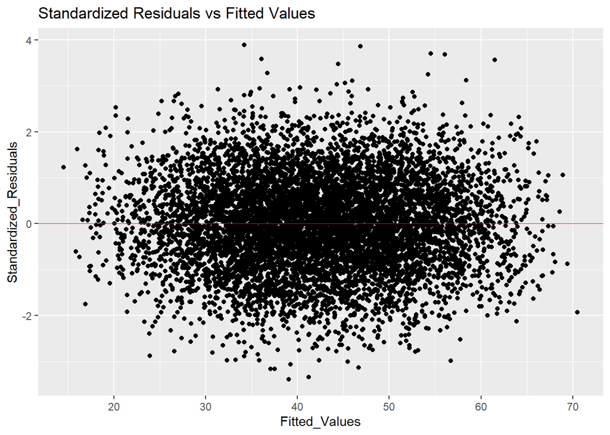

```r
# Fitted values Scatter Plot
ggplot(data=fittedData, aes(x=Fitted_Values, y=Standardized_Residuals)) +
  geom_point(color='black') +
  ggtitle("Standardized Residuals vs Fitted Values") +
  geom_hline(yintercept=0, color="red", size=0.3)
```

**4. NORMALITY**

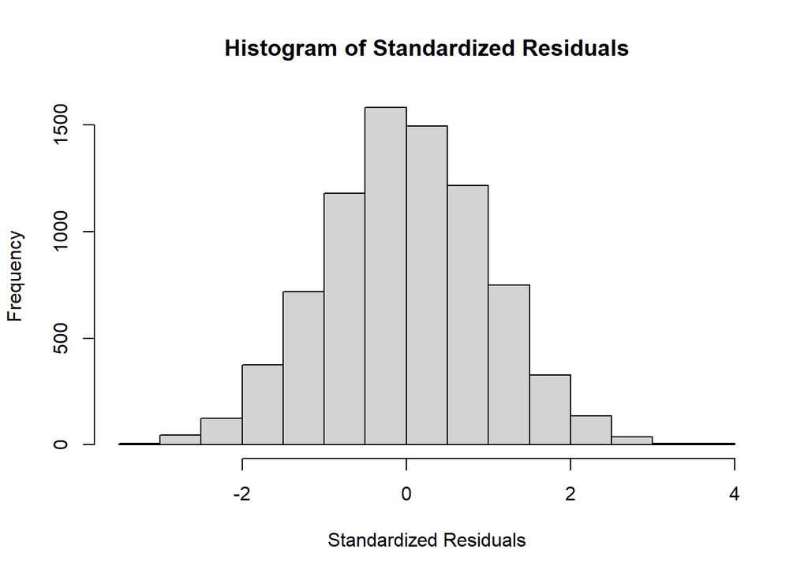

```r
# histogram of standardized residuals: check normality, constant var, uncorr errors
std.resids <- rstandard(model.full)
hist(std.resids,main="Histogram of Standardized Residuals",  xlab="Standardized Residuals")
```

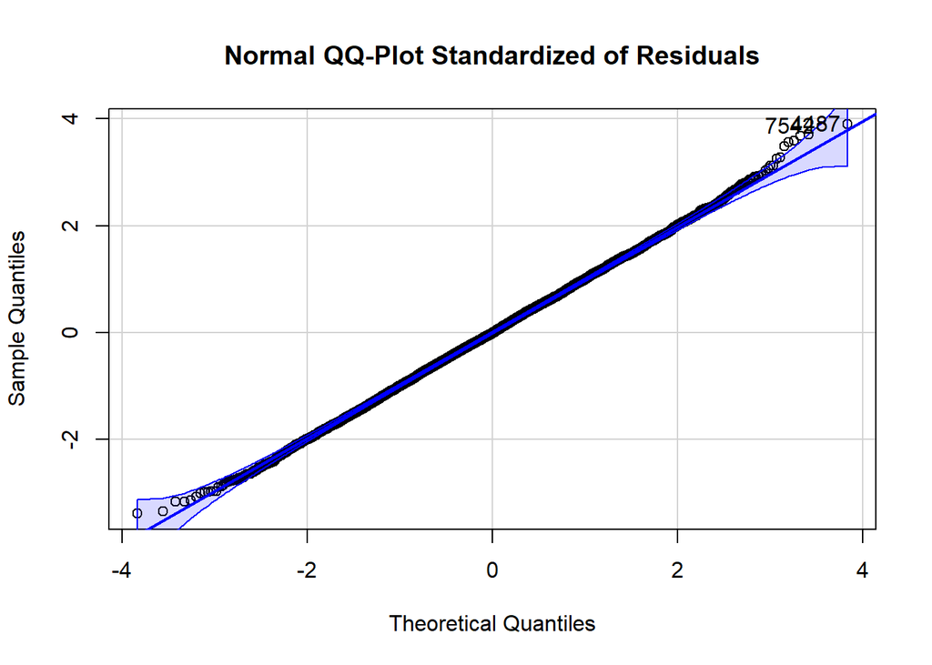

```
## 4487 7542
## 6350 1593
```

```r
# Q-Q plot: check normality
qqPlot(std.resids, main="Normal QQ-Plot Standardized of Residuals", envelope=0.95,
      xlab="Theoretical Quantiles", ylab="Sample Quantiles")
```

### Multi-collinearity

```r
vif.threshold <- 5

vif.model.full <- round(vif(model.full),3)
vif.model.full <- as.data.frame(vif.model.full)
vif.model.full$exceedsThreshold <- ifelse(vif.model.full$GVIF > vif.threshold, "True", "False")
kable(vif.model.full, caption = "Model1 VIFs")
```

Model1 VIFs

|  | GVIF | Df | GVIF^(1/(2*Df)) | exceedsThreshold |
| --- | --- | --- | --- | --- |
| Age | 1.003 | 1 | 1.001 | False |
| Salary | 1.003 | 1 | 1.002 | False |
| Experience | 1.003 | 1 | 1.002 | False |
| Education_Level | 1.016 | 4 | 1.002 | False |
| Job_Satisfaction | 1.012 | 4 | 1.002 | False |
| Department | 1.013 | 5 | 1.001 | False |
| Work_Life_Balance | 1.012 | 4 | 1.001 | False |
| Annual_Bonus | 1.006 | 1 | 1.003 | False |
| Commute_Time | 1.005 | 1 | 1.002 | False |
| Work_Hours_Per_Week | 1.003 | 1 | 1.001 | False |
| Promotions_Last_5_Years | 1.010 | 4 | 1.001 | False |
| Training_Hours_Last_Year | 1.004 | 1 | 1.002 | False |
| Overtime_Hours_Per_Week | 1.003 | 1 | 1.001 | False |

### Outliers

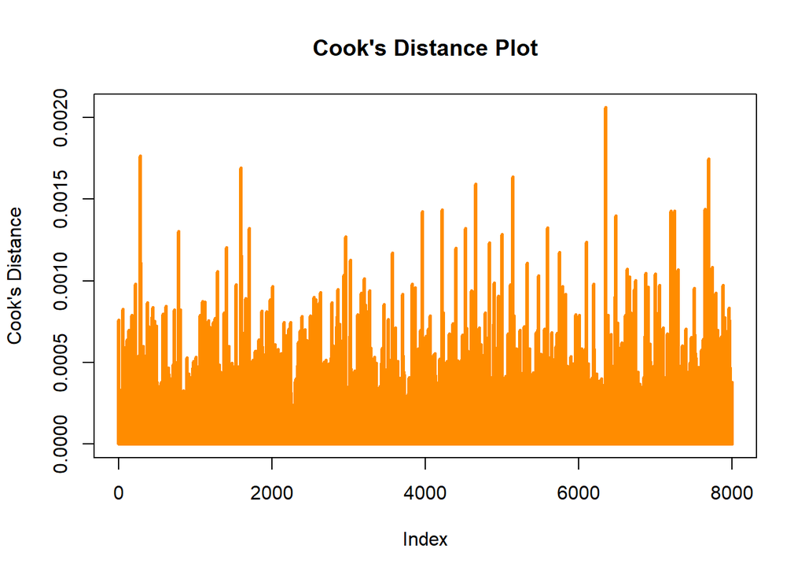

```r
cooks.threshold <- 1

# plot Cook’s distances for model1
cook = cooks.distance(model.full)
plot(cook, type="h", lwd=3,col="darkorange",
  ylab = "Cook's Distance", main="Cook's Distance Plot")
abline(h = cooks.threshold, lty = 2, col = "darkblue")
```

### Stepwise Variable Selection: Forward, Backward, Forward-Backward

minimum model: The minimum model used for stepwise regression was the intercept-only model. This is because there are not controlling variables that we must enter in the model along with the intercept.

selection criteria: The AIC was used as the criteria to add variables in forward stepwise and remove variables in backward regression.

Forward-selection:

- AIC: 59485.7
- BIC: 59555.57
- variables selected: (Intercept), Experience, Work_Hours_Per_Week, Age, Education_LevelBachelor, Education_LevelHigh School, Education_LevelMaster, Education_LevelPhD, Annual_Bonus

- AIC: AIC: 59485.7
- BIC: 59555.57
- variables selected: (Intercept), Experience, Work_Hours_Per_Week, Age, Education_LevelBachelor, Education_LevelHigh School, Education_LevelMaster, Education_LevelPhD, Annual_Bonus

#### Forward-Selection

```r
### Apply Stepwise to training data
full.model <- lm(Performance_Score~., data=trainData)

minimum.model <- lm(Performance_Score~1, data=trainData)

# Forward
stepwise_forward <- step(minimum.model ,scope = list(lower=minimum.model,upper=full.model), direction = "forward", k=2)
```

```
## Start:  AIC=42014.38
## Performance_Score ~ 1
##
##                            Df Sum of Sq     RSS   AIC
## + Experience                1    408410 1118481 39526
## + Work_Hours_Per_Week       1    169121 1357770 41077
## + Age                       1    162944 1363946 41114
## + Salary                    1      1049 1525841 42011
## + Education_Level           4      2085 1524805 42011
## + Annual_Bonus              1       934 1525956 42011
## + Training_Hours_Last_Year  1       644 1526247 42013
## + Commute_Time              1       532 1526358 42014
## <none>                                  1526890 42014
## + Work_Life_Balance         4      1307 1525583 42016
## + Overtime_Hours_Per_Week   1        51 1526839 42016
## + Job_Satisfaction          4      1092 1525798 42017
## + Promotions_Last_5_Years   4      1045 1525846 42017
## + Department                5       847 1526043 42020
##
## Step:  AIC=39526.28
## Performance_Score ~ Experience
##
##                            Df Sum of Sq     RSS   AIC
## + Work_Hours_Per_Week       1    167586  950895 38230
## + Age                       1    159823  958657 38295
## + Annual_Bonus              1       971 1117509 39521
## + Education_Level           4      1547 1116934 39523
## + Commute_Time              1       300 1118181 39526
## <none>                                  1118481 39526
## + Salary                    1       253 1118228 39526
## + Training_Hours_Last_Year  1       195 1118285 39527
## + Overtime_Hours_Per_Week   1        91 1118390 39528
## + Job_Satisfaction          4       841 1117639 39528
## + Work_Life_Balance         4       774 1117706 39529
## + Promotions_Last_5_Years   4       498 1117983 39531
## + Department                5       312 1118168 39534
##
## Step:  AIC=38229.69
## Performance_Score ~ Experience + Work_Hours_Per_Week
##
```

[output cut: 45 more lines]

```
##
## Step:  AIC=36780.68
## Performance_Score ~ Experience + Work_Hours_Per_Week + Age +
##     Education_Level + Annual_Bonus
##
##                            Df Sum of Sq    RSS   AIC
## <none>                                  792170 36781
## + Salary                    1    116.11 792054 36782
## + Training_Hours_Last_Year  1     87.98 792082 36782
## + Commute_Time              1     78.38 792092 36782
## + Work_Life_Balance         4    667.64 791503 36782
## + Overtime_Hours_Per_Week   1     56.87 792114 36782
## + Job_Satisfaction          4    525.74 791645 36783
## + Promotions_Last_5_Years   4    135.44 792035 36787
## + Department                5    282.01 791888 36788
```

```r
summary(stepwise_forward)
```

```
##
## Call:
## lm(formula = Performance_Score ~ Experience + Work_Hours_Per_Week +
##     Age + Education_Level + Annual_Bonus, data = trainData)
##
## Residuals:
##     Min      1Q  Median      3Q     Max
## -34.197  -6.638  -0.073   6.626  38.651
##
## Coefficients:
##                              Estimate Std. Error t value Pr(>|t|)
## (Intercept)                 1.3419730  0.6576965   2.040  0.04134 *
## Experience                  0.5041285  0.0079033  63.787  < 2e-16 ***
## Work_Hours_Per_Week         0.3930627  0.0096420  40.766  < 2e-16 ***
## Age                         0.2968625  0.0074760  39.709  < 2e-16 ***
## Education_LevelBachelor     0.4526940  0.3502875   1.292  0.19627
## Education_LevelHigh School  0.2013401  0.3526622   0.571  0.56807
## Education_LevelMaster       0.8419085  0.3483728   2.417  0.01568 *
## Education_LevelPhD          1.0597350  0.3532437   3.000  0.00271 **
## Annual_Bonus               -0.0001249  0.0000560  -2.231  0.02571 *
## ---
## Signif. codes:  0 '***' 0.001 '**' 0.01 '*' 0.05 '.' 0.1 ' ' 1
##
## Residual standard error: 9.957 on 7991 degrees of freedom
## Multiple R-squared:  0.4812, Adjusted R-squared:  0.4807
## F-statistic: 926.4 on 8 and 7991 DF,  p-value: < 2.2e-16
```

```r
n = nrow(trainData)
# selected variables
coef(stepwise_forward)
```

```
##                (Intercept)                 Experience
##               1.3419729965               0.5041285015
##        Work_Hours_Per_Week                        Age
##               0.3930626489               0.2968625412
##    Education_LevelBachelor Education_LevelHigh School
##               0.4526940104               0.2013400612
##      Education_LevelMaster         Education_LevelPhD
##               0.8419084830               1.0597349873
##               Annual_Bonus
##              -0.0001249275
```

```r
# AIC and BIC
cat("AIC:", AIC(stepwise_forward, k=2),"\n")
```

```
## AIC: 59485.7
```

```r
cat("BIC:", AIC(stepwise_forward, k=log(n)))
```

```
## BIC: 59555.57
```

```r
# Backward
stepwise_backward <- step(minimum.model ,scope = list(lower=minimum.model,upper=full.model), direction = "forward", k=2)
```

```
## Start:  AIC=42014.38
## Performance_Score ~ 1
##
##                            Df Sum of Sq     RSS   AIC
## + Experience                1    408410 1118481 39526
## + Work_Hours_Per_Week       1    169121 1357770 41077
## + Age                       1    162944 1363946 41114
## + Salary                    1      1049 1525841 42011
## + Education_Level           4      2085 1524805 42011
## + Annual_Bonus              1       934 1525956 42011
## + Training_Hours_Last_Year  1       644 1526247 42013
## + Commute_Time              1       532 1526358 42014
## <none>                                  1526890 42014
## + Work_Life_Balance         4      1307 1525583 42016
## + Overtime_Hours_Per_Week   1        51 1526839 42016
## + Job_Satisfaction          4      1092 1525798 42017
## + Promotions_Last_5_Years   4      1045 1525846 42017
## + Department                5       847 1526043 42020
##
## Step:  AIC=39526.28
## Performance_Score ~ Experience
##
##                            Df Sum of Sq     RSS   AIC
## + Work_Hours_Per_Week       1    167586  950895 38230
## + Age                       1    159823  958657 38295
## + Annual_Bonus              1       971 1117509 39521
## + Education_Level           4      1547 1116934 39523
## + Commute_Time              1       300 1118181 39526
## <none>                                  1118481 39526
## + Salary                    1       253 1118228 39526
## + Training_Hours_Last_Year  1       195 1118285 39527
## + Overtime_Hours_Per_Week   1        91 1118390 39528
## + Job_Satisfaction          4       841 1117639 39528
## + Work_Life_Balance         4       774 1117706 39529
## + Promotions_Last_5_Years   4       498 1117983 39531
## + Department                5       312 1118168 39534
##
## Step:  AIC=38229.69
## Performance_Score ~ Experience + Work_Hours_Per_Week
##
```

[output cut: 45 more lines]

```
##
## Step:  AIC=36780.68
## Performance_Score ~ Experience + Work_Hours_Per_Week + Age +
##     Education_Level + Annual_Bonus
##
##                            Df Sum of Sq    RSS   AIC
## <none>                                  792170 36781
## + Salary                    1    116.11 792054 36782
## + Training_Hours_Last_Year  1     87.98 792082 36782
## + Commute_Time              1     78.38 792092 36782
## + Work_Life_Balance         4    667.64 791503 36782
## + Overtime_Hours_Per_Week   1     56.87 792114 36782
## + Job_Satisfaction          4    525.74 791645 36783
## + Promotions_Last_5_Years   4    135.44 792035 36787
## + Department                5    282.01 791888 36788
```

```r
# selected variables
coef(stepwise_backward)
```

```
##                (Intercept)                 Experience
##               1.3419729965               0.5041285015
##        Work_Hours_Per_Week                        Age
##               0.3930626489               0.2968625412
##    Education_LevelBachelor Education_LevelHigh School
##               0.4526940104               0.2013400612
##      Education_LevelMaster         Education_LevelPhD
##               0.8419084830               1.0597349873
##               Annual_Bonus
##              -0.0001249275
```

```r
# AIC and BIC
cat("AIC:", AIC(stepwise_backward, k=2),"\n")
```

```
## AIC: 59485.7
```

```r
cat("BIC:", AIC(stepwise_backward, k=log(n)))
```

```
## BIC: 59555.57
```

```r
# Both
fwd_bkwd_model<- step(minimum.model ,scope = list(lower=minimum.model,upper=full.model), direction = "forward", k=2)
```

```
## Start:  AIC=42014.38
## Performance_Score ~ 1
##
##                            Df Sum of Sq     RSS   AIC
## + Experience                1    408410 1118481 39526
## + Work_Hours_Per_Week       1    169121 1357770 41077
## + Age                       1    162944 1363946 41114
## + Salary                    1      1049 1525841 42011
## + Education_Level           4      2085 1524805 42011
## + Annual_Bonus              1       934 1525956 42011
## + Training_Hours_Last_Year  1       644 1526247 42013
## + Commute_Time              1       532 1526358 42014
## <none>                                  1526890 42014
## + Work_Life_Balance         4      1307 1525583 42016
## + Overtime_Hours_Per_Week   1        51 1526839 42016
## + Job_Satisfaction          4      1092 1525798 42017
## + Promotions_Last_5_Years   4      1045 1525846 42017
## + Department                5       847 1526043 42020
##
## Step:  AIC=39526.28
## Performance_Score ~ Experience
##
##                            Df Sum of Sq     RSS   AIC
## + Work_Hours_Per_Week       1    167586  950895 38230
## + Age                       1    159823  958657 38295
## + Annual_Bonus              1       971 1117509 39521
## + Education_Level           4      1547 1116934 39523
## + Commute_Time              1       300 1118181 39526
## <none>                                  1118481 39526
## + Salary                    1       253 1118228 39526
## + Training_Hours_Last_Year  1       195 1118285 39527
## + Overtime_Hours_Per_Week   1        91 1118390 39528
## + Job_Satisfaction          4       841 1117639 39528
## + Work_Life_Balance         4       774 1117706 39529
## + Promotions_Last_5_Years   4       498 1117983 39531
## + Department                5       312 1118168 39534
##
## Step:  AIC=38229.69
## Performance_Score ~ Experience + Work_Hours_Per_Week
##
```

[output cut: 45 more lines]

```
##
## Step:  AIC=36780.68
## Performance_Score ~ Experience + Work_Hours_Per_Week + Age +
##     Education_Level + Annual_Bonus
##
##                            Df Sum of Sq    RSS   AIC
## <none>                                  792170 36781
## + Salary                    1    116.11 792054 36782
## + Training_Hours_Last_Year  1     87.98 792082 36782
## + Commute_Time              1     78.38 792092 36782
## + Work_Life_Balance         4    667.64 791503 36782
## + Overtime_Hours_Per_Week   1     56.87 792114 36782
## + Job_Satisfaction          4    525.74 791645 36783
## + Promotions_Last_5_Years   4    135.44 792035 36787
## + Department                5    282.01 791888 36788
```

```r
# filter for coefficients with a p-value <0.01
which(summary(fwd_bkwd_model)$coeff[,4]<0.01)
```

```
##          Experience Work_Hours_Per_Week                 Age  Education_LevelPhD
##                   2                   3                   4                   8
```

```r
# selected variables
coef(fwd_bkwd_model)
```

```
##                (Intercept)                 Experience
##               1.3419729965               0.5041285015
##        Work_Hours_Per_Week                        Age
##               0.3930626489               0.2968625412
##    Education_LevelBachelor Education_LevelHigh School
##               0.4526940104               0.2013400612
##      Education_LevelMaster         Education_LevelPhD
##               0.8419084830               1.0597349873
##               Annual_Bonus
##              -0.0001249275
```

```r
# AIC and BIC
cat("AIC:", AIC(fwd_bkwd_model, k=2),"\n")
```

```
## AIC: 59485.7
```

```r
cat("BIC:", AIC(fwd_bkwd_model, k=log(n)))
```

```
## BIC: 59555.57
```

### Model Comparison

```r
stepwise_model = lm(Performance_Score ~ Experience+Work_Hours_Per_Week+Age+Education_Level+Annual_Bonus, data=trainData)

stepwise_signif_only = lm(Performance_Score ~ Experience+Work_Hours_Per_Week+Age+Education_Level, data=trainData)
```

```r
# compare full and stepwise
anova(model.full, stepwise_model)
```

```
## Analysis of Variance Table
##
## Model 1: Performance_Score ~ Age + Salary + Experience + Education_Level +
##     Job_Satisfaction + Department + Work_Life_Balance + Annual_Bonus +
##     Commute_Time + Work_Hours_Per_Week + Promotions_Last_5_Years +
##     Training_Hours_Last_Year + Overtime_Hours_Per_Week
## Model 2: Performance_Score ~ Experience + Work_Hours_Per_Week + Age +
##     Education_Level + Annual_Bonus
##   Res.Df    RSS  Df Sum of Sq      F Pr(>F)
## 1   7970 790267
## 2   7991 792170 -21   -1903.8 0.9143 0.5723
```

For anova(model.full, stepwise): The p-value is large in the ANOVA test comparing the full regression to the model selected with stepwise. This means we cannot reject the null hypothesis. The two models are not statistically significantly different at the 0.05 level. Hence, choose the reduced model becuase it has fewer predicting variables.

```r
anova(stepwise_model, stepwise_signif_only)
```

```
## Analysis of Variance Table
##
## Model 1: Performance_Score ~ Experience + Work_Hours_Per_Week + Age +
##     Education_Level + Annual_Bonus
## Model 2: Performance_Score ~ Experience + Work_Hours_Per_Week + Age +
##     Education_Level
##   Res.Df    RSS Df Sum of Sq      F  Pr(>F)
## 1   7991 792170
## 2   7992 792664 -1   -493.41 4.9773 0.02571 *
## ---
## Signif. codes:  0 '***' 0.001 '**' 0.01 '*' 0.05 '.' 0.1 ' ' 1
```

For anova(stepwise, signif_stepwise): The p-value is less than 0.05. This means there’s at least one variable in stepwise_model that will improve the explanatory power of the model. Hence, choose stepwise_model over further reduced one.

### Regularized Regression for Variable Selection:

LASSO. Group LASSO, and Elastic Net are three regularized regression models that can be used for regularized regression. Elastic Net often outperforms LASSO, since Elastic Net leverages the L1 and L2 penalties, so it has the advantages of both LASSO and Ridge regression, whereas LASSO only uses the L1 penalty.

glmnet() will re-scale the predictor variables for regularized regression

```r
set.seed(123)
# format predictors and response
x.train <- model.matrix(Performance_Score ~ ., trainData)[,-1]
y.train <- trainData$Performance_Score
```

### Lasso

```r
# LASSO
set.seed(123)
## Find optimal lambda with 10-fold CV
lasso_model.cv = cv.glmnet(x.train,  y.train, alpha=1, nfolds=10)

cat("optimal lambda:", lasso_model.cv$lambda.min)
```

```
## optimal lambda: 0.09895032
```

```r
set.seed(123)
## Fit lasso model with 100 values for lambda
lasso_model = glmnet(x.train, y.train, alpha=1, nlambda=100)

## coefficients at optimal lambda
coef(lasso_model, s=lasso_model.cv$lambda.min)
```

```
## 30 x 1 sparse Matrix of class "dgCMatrix"
##                                       s1
## (Intercept)                 2.254796e+00
## Age                         2.904225e-01
## Salary                     -1.856718e-06
## Experience                  4.969955e-01
## Education_LevelBachelor     .
## Education_LevelHigh School  .
## Education_LevelMaster       2.993671e-01
## Education_LevelPhD          5.296370e-01
## Job_Satisfaction2           .
## Job_Satisfaction3           .
## Job_Satisfaction4           .
## Job_Satisfaction5           2.365840e-01
## DepartmentFinance           .
## DepartmentHR                .
## DepartmentMarketing        -1.232129e-01
## DepartmentOperations        .
## DepartmentSales             .
## Work_Life_Balance2         -9.835074e-02
## Work_Life_Balance3         -1.302690e-02
## Work_Life_Balance4          3.257603e-01
## Work_Life_Balance5          .
## Annual_Bonus               -7.593338e-05
## Commute_Time                .
## Work_Hours_Per_Week         3.846670e-01
## Promotions_Last_5_Years1   -4.868607e-04
## Promotions_Last_5_Years2    .
## Promotions_Last_5_Years3    .
## Promotions_Last_5_Years4    .
## Training_Hours_Last_Year   -9.457607e-06
## Overtime_Hours_Per_Week     .
```

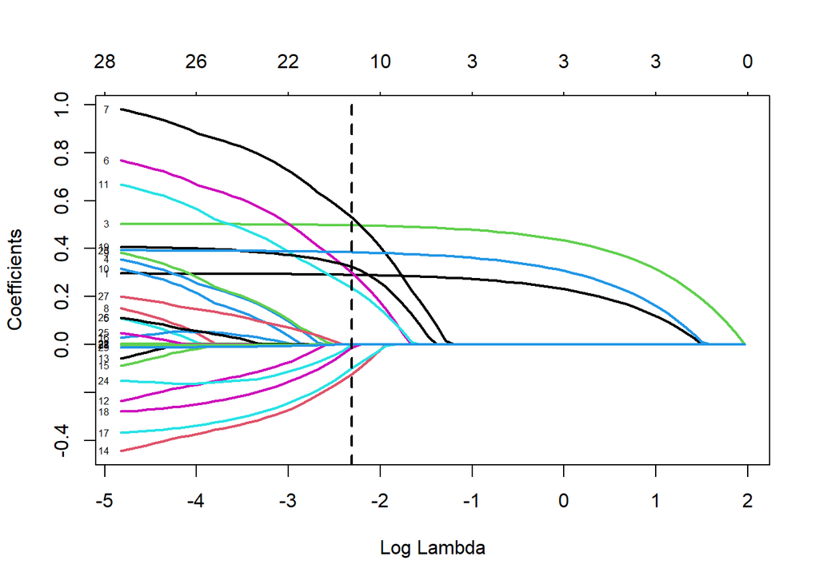

```r
## Plot coefficient paths
plot(lasso_model , xvar="lambda", lwd=2, label=TRUE)
abline(v=log(lasso_model.cv$lambda.min), col='black', lty=2, lwd=2)
```

### Elastic Net

```r
set.seed(123)
# Find the optimal lambda using 10-fold CV for ELASTIC NET
elastic_net_model.cv <- cv.glmnet(x.train, y.train, alpha=0.5, nfolds=10)

cat("optimal lambda:", elastic_net_model.cv$lambda.min)
```

```
## optimal lambda: 0.1803197
```

```r
# fit model for 100 values for lambda
elastic_net_model <- glmnet(x = x.train, y = y.train, alpha=0.5, nlambda=100)

## Extract coefficients at optimal lambda
coef(elastic_net_model, s=elastic_net_model.cv$lambda.min)
```

```
## 30 x 1 sparse Matrix of class "dgCMatrix"
##                                       s1
## (Intercept)                 2.503341e+00
## Age                         2.891080e-01
## Salary                     -2.489804e-06
## Experience                  4.943377e-01
## Education_LevelBachelor     .
## Education_LevelHigh School  .
## Education_LevelMaster       3.273450e-01
## Education_LevelPhD          5.574981e-01
## Job_Satisfaction2           .
## Job_Satisfaction3           .
## Job_Satisfaction4           .
## Job_Satisfaction5           2.568394e-01
## DepartmentFinance           .
## DepartmentHR                .
## DepartmentMarketing        -1.450935e-01
## DepartmentOperations        .
## DepartmentSales             .
## Work_Life_Balance2         -1.249001e-01
## Work_Life_Balance3         -4.169108e-02
## Work_Life_Balance4          3.328637e-01
## Work_Life_Balance5          .
## Annual_Bonus               -8.007385e-05
## Commute_Time                2.383313e-04
## Work_Hours_Per_Week         3.829552e-01
## Promotions_Last_5_Years1   -2.485688e-02
## Promotions_Last_5_Years2    .
## Promotions_Last_5_Years3    .
## Promotions_Last_5_Years4    .
## Training_Hours_Last_Year   -3.487529e-04
## Overtime_Hours_Per_Week     .
```

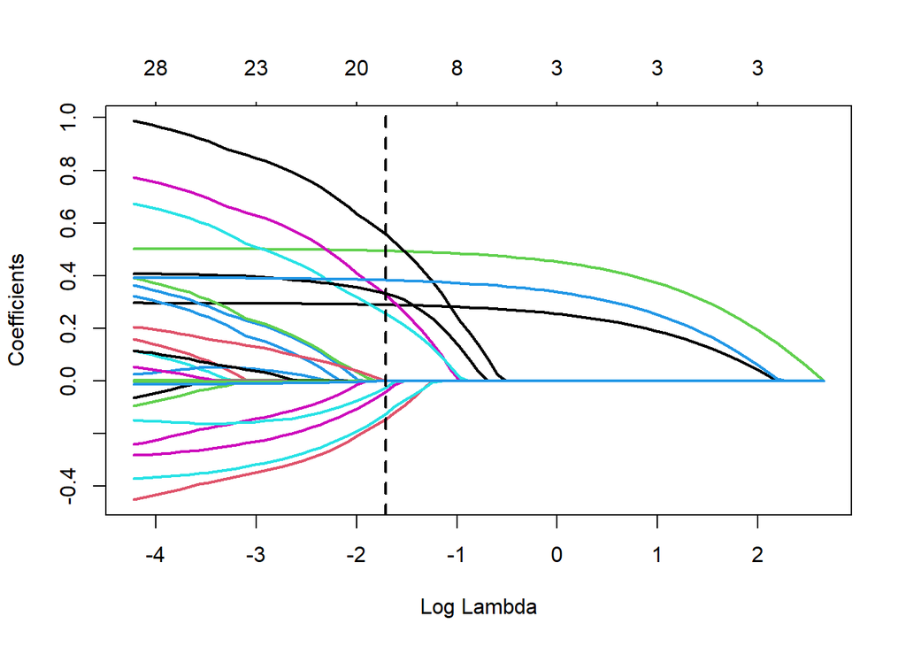

```r
set.seed(123)
## Plot coefficient paths
plot(elastic_net_model, xvar="lambda", lwd=2)
abline(v=log(elastic_net_model.cv$lambda.min), col='black', lty=2, lwd=2)
```

### Decision Tree

```r
library(rpart)
library(rpart.plot)
set.seed(123)
# Build the decision tree model
decision_tree_model <- rpart(Performance_Score ~ ., data = trainData, method = "anova")

# Print the model summary
summary(decision_tree_model)
```

```
## Call:
## rpart(formula = Performance_Score ~ ., data = trainData, method = "anova")
##   n= 8000
##
##           CP nsplit rel error    xerror       xstd
## 1 0.20905926      0 1.0000000 1.0001897 0.01528949
## 2 0.04937652      1 0.7909407 0.7912448 0.01245097
## 3 0.04052615      2 0.7415642 0.7420581 0.01178268
## 4 0.02166298      3 0.7010381 0.7062761 0.01113353
## 5 0.02061462      4 0.6793751 0.6851474 0.01083203
## 6 0.01931664      5 0.6587605 0.6746218 0.01069350
## 7 0.01770286      6 0.6394438 0.6549539 0.01033252
## 8 0.01000000      7 0.6217410 0.6289240 0.00988532
##
## Variable importance
##          Experience Work_Hours_Per_Week                 Age              Salary
##                  54                  23                  21                   1
##
## Node number 1: 8000 observations,    complexity param=0.2090593
##   mean=42.36135, MSE=190.8613
##   left son=2 (4238 obs) right son=3 (3762 obs)
##   Primary splits:
##       Experience          < 26.5     to the left,  improve=0.209059300, (0 missing)
##       Work_Hours_Per_Week < 38.5     to the left,  improve=0.090297220, (0 missing)
##       Age                 < 46.5     to the left,  improve=0.083245470, (0 missing)
##       Annual_Bonus        < 5111.61  to the right, improve=0.001318983, (0 missing)
##       Commute_Time        < 114.5    to the left,  improve=0.001112022, (0 missing)
##   Surrogate splits:
##       Salary                   < 81493.7  to the left,  agree=0.532, adj=0.005, (0 split)
##       Commute_Time             < 117.5    to the left,  agree=0.532, adj=0.004, (0 split)
##       Annual_Bonus             < 10023.2  to the left,  agree=0.531, adj=0.003, (0 split)
##       Age                      < 67.5     to the left,  agree=0.531, adj=0.002, (0 split)
##       Training_Hours_Last_Year < 5.5      to the right, agree=0.530, adj=0.001, (0 split)
##
## Node number 2: 4238 observations,    complexity param=0.04937652
##   mean=36.40991, MSE=148.3988
##   left son=4 (2183 obs) right son=5 (2055 obs)
##   Primary splits:
##       Work_Hours_Per_Week < 40.5     to the left,  improve=0.119877300, (0 missing)
##       Age                 < 48.5     to the left,  improve=0.100262800, (0 missing)
```

[output cut: 89 more lines]

```
##
## Node number 11: 834 observations
##   mean=45.61141, MSE=115.6161
##
## Node number 12: 718 observations
##   mean=39.98734, MSE=120.3826
##
## Node number 13: 1019 observations
##   mean=47.99815, MSE=126.8505
##
## Node number 14: 840 observations
##   mean=48.13931, MSE=123.2948
##
## Node number 15: 1185 observations
##   mean=56.14143, MSE=117.3983
```

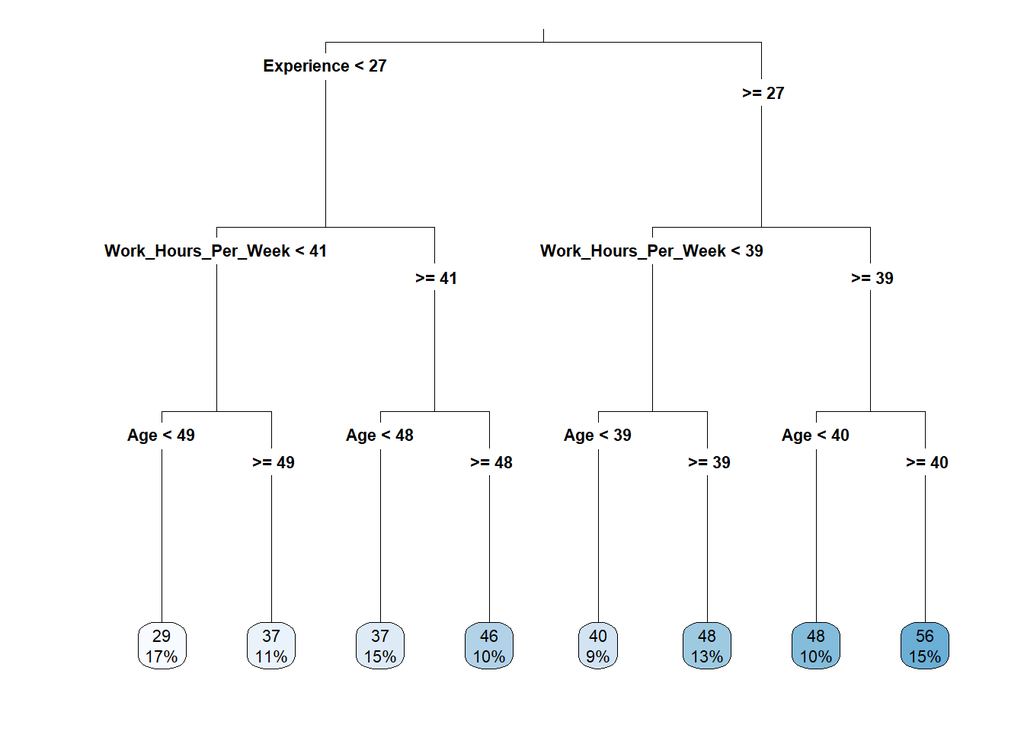

```r
rpart.plot(decision_tree_model, type = 3, fallen.leaves = TRUE, cex = 0.7)
```

### Random Forest

```r
set.seed(123)
library(randomForest)

# for random forest
rf_model <- randomForest(trainData$Performance_Score~.,data = trainData)
```

### Make Predictions

```r
## PREDICTIONS
y.test <- testData$Performance_Score

# full model
predict.full <- predict(model.full,newdata=testData)

# stepwise
predict.stepwise <- predict(stepwise_model,newdata=testData)

# LASSO
# Retrain OLS using Lasso-selected predictors for better coeff estimates
index.lasso <- which(coef(lasso_model, lasso_model.cv$lambda.min) == 0)
lasso.predictors <- as.data.frame(x.train)[-(index.lasso-1)]
lasso.retrained <- glm(y.train ~ ., data = lasso.predictors)
# Set test data to correct format
new_test <- model.matrix( ~ ., data=testData)[,-1]
# get predicted probabilities for the test set
predict.lasso = predict(lasso.retrained, newdata = as.data.frame(new_test),
                     type = "response")

# decision tree
predict.dtree <- predict(decision_tree_model, testData)

# random forest
predict.rf <- predict(rf_model, testData, type="response")

# function for predictions
pred_metrics = function(model_name, actual, pred){
  cat("\n", model_name, "\n")
  mspe = mean((actual - pred)^2)
  mae = mean(abs(actual-pred))
  cat("mspe:", mspe, "\n", "mae:", mae, "\n")
}

# metrics for full model
pred_metrics("Full Regression", y.test, predict.full)
```

```
##
##  Full Regression
## mspe: 101.201
##  mae: 7.940675
```

```r
# metrics for forward stepwise
pred_metrics("Stepwise", y.test, predict.stepwise)
```

```
##
##  Stepwise
## mspe: 101.1876
##  mae: 7.932867
```

```r
# metrics for lasso
pred_metrics("LASSO", y.test, predict.lasso)
```

```
##
##  LASSO
## mspe: 101.094
##  mae: 7.936827
```

```r
# metrics for decision tree
pred_metrics("Decision Tree", y.test, predict.dtree)
```

```
##
##  Decision Tree
## mspe: 124.1864
##  mae: 8.812438
```

```r
# metrics for random forest
pred_metrics("Random Forest Model", y.test, predict.rf)
```

```
##
##  Random Forest Model
## mspe: 105.2443
##  mae: 8.102373
```

```r
# adjusted r-squared for training set
# summary(model.full)$adj.r.squared
# summary(stepwise_model)$adj.r.squared
```